# User Photos Experiment - casocha

## 1. Package Imports, Initial Data Read In, & Basic Data Check

```python
import numpy as np
import pandas as pd
import matplotlib.pyplot as plt
import seaborn as sns
%matplotlib inline

df = pd.read_csv(r'C:\Users\casocha\Documents\Photos/userPhotos.csv')
```

```python
#df.isnull().values.any()
#df.describe()
#df.head()
#df.info()
```

```python
df['FinalOneDriveSettingState'] = df['FinalOneDriveSettingState'].fillna('EnableOneDrive')
df['FinalDuplicateSettingState'] = df['FinalDuplicateSettingState'].fillna('EnableHideDuplicatedItems')
df['FinalEnhanceSettingState'] = df['FinalEnhanceSettingState'].fillna('EnableAutoEnhance')

df[['FinalOneDriveSettingState','FinalDuplicateSettingState','FinalEnhanceSettingState']] = df[['FinalOneDriveSettingState','FinalDuplicateSettingState','FinalEnhanceSettingState']].astype('bool')

df[['IsTouchEnabled','FinalOneDriveSettingState','FinalDuplicateSettingState','FinalEnhanceSettingState']] = (df[['IsTouchEnabled','FinalOneDriveSettingState','FinalDuplicateSettingState','FinalEnhanceSettingState']]).astype(int)

#Get initial df count
df.shape
```

```
(71696, 50)
```

## 2. Replace null values

1. Sets the nulls in these 3 columns to default value from data description
   - FinalOneDriveSettingState default value = EnableOneDrive
   - FinalDuplicateSettingState default value = EnableHideDuplicatedItems
   - FinalEnhanceSettingState default value = EnableAutoEnhance
2. Convert string values into numbers
3. Unsure of what to replace nulls with in FormFactor & CountryShortName
   - Null row count is low in both so I decided to drop the rows

```python
#checks for null values
#df.FormFactor.isnull().sum()
#df.CountryShortName.isnull().sum()
#drops null rows
df = df.dropna(subset=['FormFactor','CountryShortName'])
#check if values properly dropped
df.shape
```

```
(71047, 50)
```

```python
s = df.groupby('CountryShortName')['AgeGroup'].value_counts().to_frame()
s = df.groupby('CountryShortName')['AgeGroup'].first().to_frame()
s['AgeGroup'] = s['AgeGroup'].fillna('[25-35)')
```

```python
s2 = df.groupby('CountryShortName')['Gender'].value_counts().to_frame()
s2 = df.groupby('CountryShortName')['Gender'].first().to_frame()
s2['Gender'] = s2['Gender'].fillna('M')
```

```python
s3 = s.to_dict()
s3 = s3['AgeGroup']

s4 = s2.to_dict()
s4 = s4['Gender']
```

- Recalculated the total time in other photo apps based on available data & data descriptions
- Head print out to double check calculations

```python
df['TotalTimeInOtherPhotosAppsInMins'] = df['TotalTimeInAllPhotosAppsInMins'] - df['TotalTimeInPhotosAppInMins']
df[['TotalTimeInAllPhotosAppsInMins','TotalTimeInPhotosAppInMins','TotalTimeInOtherPhotosAppsInMins']].head(10)
```

|  | TotalTimeInAllPhotosAppsInMins | TotalTimeInPhotosAppInMins | TotalTimeInOtherPhotosAppsInMins |
| --- | --- | --- | --- |
| 1 | 1203 | 0 | 1203 |
| 2 | 0 | 0 | 0 |
| 3 | 6 | 6 | 0 |
| 4 | 17 | 8 | 9 |
| 5 | 1 | 0 | 1 |
| 6 | 1 | 1 | 0 |
| 7 | 61 | 61 | 0 |
| 8 | 1 | 1 | 0 |
| 9 | 20 | 20 | 0 |
| 10 | 17 | 5 | 12 |

```python
df['AgeGroup']=df['AgeGroup'].fillna('0')
df['Gender']=df['Gender'].fillna('0')
def replace_na(df, my_dict, col):
    my_list = []
    for index, row in df.iterrows():
        if row[col] == '0':
            my_list.append(my_dict[row['CountryShortName']])
        else:
            my_list.append(row[col])
    return my_list

df['AgeGroup'] = replace_na(df, s3, 'AgeGroup')
df['Gender'] = replace_na(df,s4,'Gender')
```

# 3. EDA

### Answer 1: Quartile values for Total Time in Apps, Photo Apps, & Other Apps

```python
quartile = df.TotalTimeInAllPhotosAppsInMins.quantile([0.25,0.5,0.75])
print(quartile)
```

```
0.25     1.0
0.50     8.0
0.75    36.0
Name: TotalTimeInAllPhotosAppsInMins, dtype: float64
```

```python
photodf = df[df['TotalTimeInPhotosAppInMins'] > df['TotalTimeInOtherPhotosAppsInMins']]
otherdf = df[df['TotalTimeInPhotosAppInMins'] < df['TotalTimeInOtherPhotosAppsInMins']]
photoquartile = photodf.TotalTimeInPhotosAppInMins.quantile([0.25,0.5,0.75])
print(photoquartile)
```

```
0.25     3.0
0.50     8.0
0.75    24.0
Name: TotalTimeInPhotosAppInMins, dtype: float64
```

```python
otherquartile = photodf.TotalTimeInOtherPhotosAppsInMins.quantile([0.25,0.5,0.75])
print(otherquartile)
```

```
0.25    0.0
0.50    0.0
0.75    1.0
Name: TotalTimeInOtherPhotosAppsInMins, dtype: float64
```

- Data is heavily skewed towards non users. Photo apps appears to have slightly more use which makes sense since it is the default app

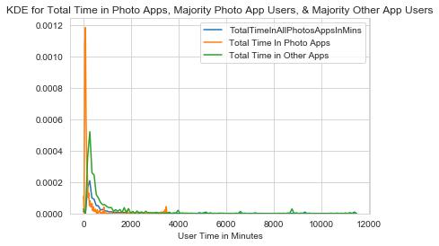

```python
sns.kdeplot(df['TotalTimeInAllPhotosAppsInMins'])
sns.kdeplot(photodf['TotalTimeInPhotosAppInMins'], bw=.2, label="Total Time In Photo Apps ")
sns.kdeplot(otherdf['TotalTimeInOtherPhotosAppsInMins'], bw=2, label="Total Time in Other Apps")
plt.title('KDE for Total Time in Photo Apps, Majority Photo App Users, & Majority Other App Users')
plt.xlabel('User Time in Minutes')
plt.show()
```

- Photo apps may have slightly more usage but other apps have higher levels of engagement.

[figure not shown]

```python
wh1 = df[['TotalTimeInAllAppsInMins','TotalTimeInPhotosAppInMins',
    'VideoTrimEdit',
'SlideShowStarted',
'ImportSessionStarted',
'ShareSessions',
'PrintSessions',
'ItemsShared',
'ItemsDelete',
'ItemsCopied',
'ItemsImported',
'FromLocal',
'FromOneDrive',
'NumberOfImages',
'NumberOfVideos',
'NumberOfPanos',
'NumberOfRichMedia',
'TotalFilesInCollection',
'NumberOfActiveDaysInOS',
    'TotalTimeInOtherPhotosAppsInMins']] #Subsetting the data
cor = wh1.corr() #Calculate the correlation of the above variables
sns.heatmap(cor, square = True) #Plot the correlation as heat map
```

- Doesnt appear to be any strong correlations in the features to total time using the photo apps besides total times in all apps

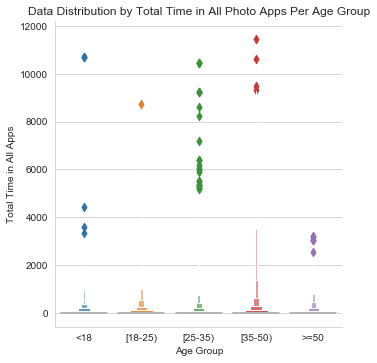

```python
sns.catplot(x="AgeGroup", y="TotalTimeInAllPhotosAppsInMins", kind="boxen",
            data=df.sort_values("AgeGroup"),order=["<18", "[18-25)",'[25-35)','[35-50)','>=50']);
plt.title("Data Distribution by Total Time in All Photo Apps Per Age Group")
plt.xlabel('Age Group')
plt.ylabel('Total Time in All Apps')
plt.show()
```

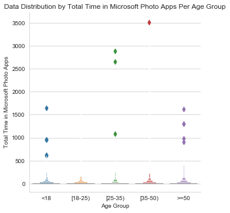

```python
sns.catplot(x="AgeGroup", y="TotalTimeInPhotosAppInMins", kind="boxen",
            data=df.sort_values("AgeGroup"),order=["<18", "[18-25)",'[25-35)','[35-50)','>=50']);
plt.title("Data Distribution by Total Time in Microsoft Photo Apps Per Age Group")
plt.xlabel('Age Group')
plt.ylabel('Total Time in Microsoft Photo Apps')
plt.show()
```

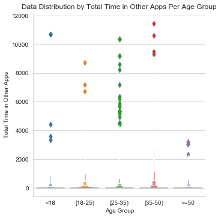

```python
sns.catplot(x="AgeGroup", y="TotalTimeInOtherPhotosAppsInMins", kind="boxen",
            data=df.sort_values("AgeGroup"),order=["<18", "[18-25)",'[25-35)','[35-50)','>=50']);
plt.title("Data Distribution by Total Time in Other Apps Per Age Group")
plt.xlabel('Age Group')
plt.ylabel('Total Time in Other Apps')
plt.show()
```

```python
df_age = df.groupby('AgeGroup')['TotalTimeInAllAppsInMins','TotalTimeInPhotosAppInMins',
                                          'TotalTimeInOtherPhotosAppsInMins'
                                          ,'TotalTimeInAllPhotosAppsInMins','NumberOfImages','NumberOfVideos',
                                         'NumberOfActiveDaysInOS','FromLocal','FromOneDrive'].apply(lambda x : x.astype(int).sum())
df202=df['AgeGroup'].value_counts().sort_index().to_frame()
df_age['total_people'] = df202['AgeGroup']
df212 = df.groupby('AgeGroup')['MostUsedPhotoApp'].value_counts().to_frame()
df212 = df.groupby('AgeGroup')['MostUsedPhotoApp'].first().to_frame()
df_age['Most_Used'] = df212['MostUsedPhotoApp']

df_age = df_age.reset_index()
df_age['Average_Days'] = df_age['NumberOfActiveDaysInOS'] / df_age['total_people']
df_age['Average_All_Apps'] = df_age['TotalTimeInAllAppsInMins'] / df_age['total_people']
df_age['Average_Photos'] = df_age['TotalTimeInPhotosAppInMins'] / df_age['total_people']
df_age['Average_Total_Photo'] = df_age['TotalTimeInAllPhotosAppsInMins'] / df_age['total_people']
df_age['Average_Others'] = df_age['TotalTimeInOtherPhotosAppsInMins'] / df_age['total_people']
df_age['Average_Pics'] = df_age['NumberOfImages'] / df_age['total_people']
df_age['Average_OneDrive'] = df_age['FromOneDrive'] / df_age['total_people']
df_age['Average_Local'] = df_age['FromLocal'] / df_age['total_people']
df_age['Photo_Other_Deficit'] = (df_age['Average_Photos'] - df_age['Average_Others']) / (df_age['Average_Photos'] + df_age['Average_Others'])
df_age['Local_One_Drive_Deficit'] = (df_age['Average_OneDrive'] - df_age['Average_Local']) / (df_age['Average_OneDrive'] + df_age['Average_Local'])
df_age.head(20)
```

|  | AgeGroup | TotalTimeInAllAppsInMins | TotalTimeInPhotosAppInMins | TotalTimeInOtherPhotosAppsInMins | TotalTimeInAllPhotosAppsInMins | NumberOfImages | NumberOfVideos | NumberOfActiveDaysInOS | FromLocal | FromOneDrive | ... | Average_Days | Average_All_Apps | Average_Photos | Average_Total_Photo | Average_Others | Average_Pics | Average_OneDrive | Average_Local | Photo_Other_Deficit | Local_One_Drive_Deficit |
| --- | --- | --- | --- | --- | --- | --- | --- | --- | --- | --- | --- | --- | --- | --- | --- | --- | --- | --- | --- | --- | --- |
| 0 | <18 | 37895316 | 95751 | 237453 | 333204 | 3579104 | 74756 | 108443 | 2808013 | 783892 | ... | 19.135874 | 6687.015352 | 16.896241 | 58.797247 | 41.901006 | 631.569437 | 138.325746 | 495.502559 | -0.425271 | -0.563523 |
| 1 | >=50 | 70569702 | 154222 | 272812 | 427034 | 13708802 | 216732 | 124926 | 8955850 | 4583204 | ... | 18.518529 | 10460.969760 | 22.861251 | 63.301808 | 40.440557 | 2032.137859 | 679.395790 | 1327.579306 | -0.277706 | -0.322965 |
| 2 | [18-25) | 122298960 | 296413 | 1029638 | 1326051 | 15479829 | 291240 | 285023 | 9841064 | 5426699 | ... | 19.161210 | 8221.778824 | 19.926924 | 89.146286 | 69.219361 | 1040.660773 | 364.820101 | 661.584134 | -0.552939 | -0.289130 |
| 3 | [25-35) | 181386538 | 470681 | 1496479 | 1967160 | 32290022 | 650418 | 523124 | 19579289 | 12121191 | ... | 18.345573 | 6361.091987 | 16.506435 | 68.986849 | 52.480414 | 1132.387235 | 425.081220 | 686.631212 | -0.521461 | -0.235268 |
| 4 | [35-50) | 145408455 | 378681 | 1462934 | 1841615 | 32856564 | 610365 | 284891 | 14854461 | 16691350 | ... | 18.688730 | 9538.733600 | 24.841315 | 120.809171 | 95.967856 | 2155.376804 | 1094.945552 | 974.446405 | -0.588751 | 0.058229 |

5 rows × 22 columns

### Initial thoughts based on age groups:

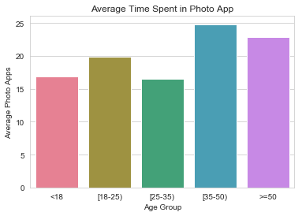

```python
age_color = sns.color_palette("husl", 5)
plt.title("Average Time Spent in Photo App")
sns.barplot(x="AgeGroup", y="Average_Photos", data=df_age,palette=age_color,
                order=["<18", "[18-25)",'[25-35)','[35-50)','>=50'])
plt.xlabel('Age Group')
plt.ylabel('Average Photo Apps')
```

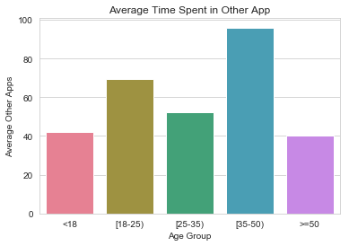

```python
plt.title("Average Time Spent in Other App")
sns.barplot(x="AgeGroup", y="Average_Others", data=df_age,palette=age_color,
            order=["<18", "[18-25)",'[25-35)','[35-50)','>=50'])
plt.xlabel('Age Group')
plt.ylabel('Average Other Apps')
```

- Graphics confirm that the 35-50 segment is most likely to spend time in other photo apps.
- 50+ segment almost matches 35-50 in photo app usage but are less likely to install / use another app.
  - Note that the graph scales are different so there is considerably more usage of non photo apps.

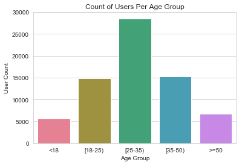

```python
plt.title("Count of Users Per Age Group")
sns.barplot(x = 'AgeGroup',y="total_people",
                data=df_age,palette=age_color,order=["<18", "[18-25)",'[25-35)','[35-50)','>=50'])
plt.xlabel('Age Group')
plt.ylabel('User Count')
```

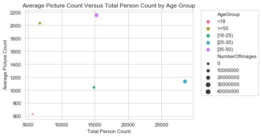

```python
plt.title("Average Picture Count Versus Total Person Count by Age Group")
sns.scatterplot(x = 'total_people',y="Average_Pics",
                hue = 'AgeGroup',data=df_age,size='NumberOfImages', palette=age_color)
plt.legend(bbox_to_anchor=(1.05, 1), loc=2, borderaxespad=0.)
plt.xlabel('Total Person Count')
plt.ylabel('Average Picture Count')
```

- 25-35 is the largest group of people but is average for picture storage
- > =50 Age group is second smallest but has second highest average storage count. They're probably primarily using it as storage

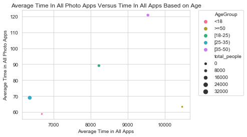

```python
sns.set_style('whitegrid')
plt.title("Average Time In All Photo Apps Versus Time In All Apps Based on Age")
sns.scatterplot(x = 'Average_All_Apps',y="Average_Total_Photo",
                hue = 'AgeGroup',data=df_age, size='total_people', palette=age_color)
plt.legend(bbox_to_anchor=(1.05, 1), loc=2, borderaxespad=0.)
plt.xlabel('Average Time in All Apps')
plt.ylabel('Average Time in All Photo Apps')
```

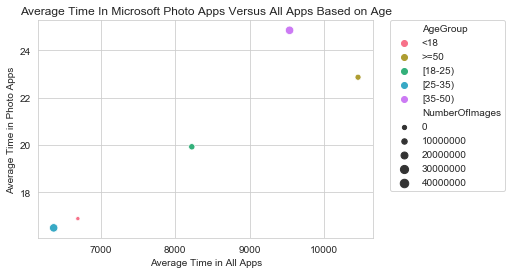

```python
plt.title("Average Time In Microsoft Photo Apps Versus All Apps Based on Age")
sns.scatterplot(x = 'Average_All_Apps',y="Average_Photos",
                hue = 'AgeGroup',data=df_age,palette=age_color,size='NumberOfImages')
plt.xlabel('Average Time in All Apps')
plt.ylabel('Average Time in Photo Apps')
plt.legend(bbox_to_anchor=(1.05, 1), loc=2, borderaxespad=0.)
```

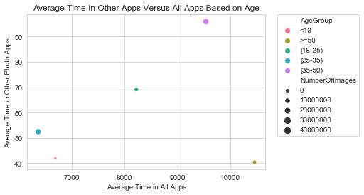

```python
plt.title("Average Time In Other Apps Versus All Apps Based on Age")
sns.scatterplot(x = 'Average_All_Apps',y="Average_Others",
                hue = 'AgeGroup',data=df_age,palette=age_color,size='NumberOfImages')
plt.xlabel('Average Time in All Apps')
plt.ylabel('Average Time in Other Photo Apps')
plt.legend(bbox_to_anchor=(1.05, 1), loc=2, borderaxespad=0.)
```

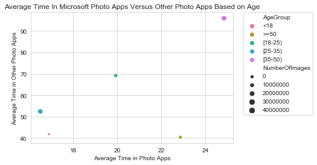

```python
plt.title("Average Time In Microsoft Photo Apps Versus Other Photo Apps Based on Age")
sns.scatterplot(x = 'Average_Photos',y="Average_Others",
                hue = 'AgeGroup',data=df_age,palette=age_color,size='NumberOfImages')
plt.xlabel('Average Time in Photo Apps')
plt.ylabel('Average Time in Other Photo Apps')
plt.legend(bbox_to_anchor=(1.05, 1), loc=2, borderaxespad=0.)
```

- The following graphics confirm that the 50+ & 35-50 are the highest users of photo apps.
- 35-50 group has a high average picture count & other app usage - this group probably contains photo professionals
- They all spend more time in other apps but the 50+ are most likely to use the photo apps
- 25-35 group seems to store a similar # of images to 35-50 but this group has a large total person advantage.

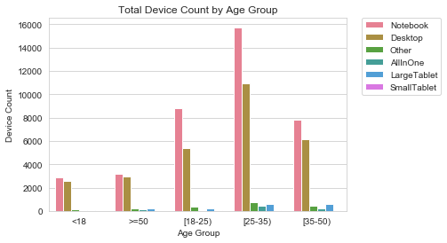

```python
df_countyyy = df.groupby(['AgeGroup'])['FormFactor'].value_counts()
df_countyyy.name = 'Form'

d = df_countyyy.to_frame()
d = d.reset_index()
age_color1 = sns.color_palette("husl", 6)
with sns.axes_style("whitegrid"):
    plt.title("Total Device Count by Age Group")
    sns.barplot(x="AgeGroup", y="Form", hue = 'FormFactor',data=d,palette=age_color1)
    plt.xlabel('Age Group')
    plt.ylabel('Device Count')
    plt.legend(bbox_to_anchor=(1.05, 1), loc=2, borderaxespad=0.)
```

- 50+ and 35-50 are relatively split between desktops & notebooks.
- To capture more of the 25-35 group it might be worth looking into the one drive usage.
- Laptops can have limited storage so greater cloud integrations or a better cloud deal could help

```python
df_age_launcher = df.groupby('AgeGroup')["TotalLaunchCount",
"LaunchViaCropPicker",
"LaunchViaWindowsCameraRoll",
"LaunchViaLumiaCameraRoll",
"LaunchViaStorageSense",
"LaunchViaDrmViewer",
"LaunchByImportProtocol",
"LaunchByImportContent",
"LaunchByTileAndTaskBar",
"LaunchBySearch",
"LaunchByFile",
"LaunchByProtocol",
"LaunchByFileOpenPicker",
"LaunchByDevice",
"LaunchByProtocolResults"].apply(lambda x : x.astype(int).sum())
df_age_launcher=df_age_launcher.reset_index()
df_age_launcher.head()
```

|  | AgeGroup | TotalLaunchCount | LaunchViaCropPicker | LaunchViaWindowsCameraRoll | LaunchViaLumiaCameraRoll | LaunchViaStorageSense | LaunchViaDrmViewer | LaunchByImportProtocol | LaunchByImportContent | LaunchByTileAndTaskBar | LaunchBySearch | LaunchByFile | LaunchByProtocol | LaunchByFileOpenPicker | LaunchByDevice | LaunchByProtocolResults |
| --- | --- | --- | --- | --- | --- | --- | --- | --- | --- | --- | --- | --- | --- | --- | --- | --- |
| 0 | <18 | 127444 | 76 | 429 | 0 | 8 | 0 | 0 | 2 | 21354 | 0 | 104339 | 844 | 87 | 173 | 7 |
| 1 | >=50 | 118820 | 158 | 170 | 0 | 59 | 0 | 1 | 28 | 15862 | 0 | 100820 | 314 | 124 | 1196 | 9 |
| 2 | [18-25) | 310652 | 197 | 1161 | 0 | 80 | 0 | 1 | 14 | 44983 | 0 | 261373 | 1617 | 170 | 690 | 23 |
| 3 | [25-35) | 612688 | 464 | 1772 | 0 | 98 | 0 | 13 | 23 | 100134 | 0 | 504558 | 3247 | 340 | 1438 | 61 |
| 4 | [35-50) | 294394 | 111 | 792 | 0 | 152 | 0 | 3 | 18 | 39921 | 0 | 249863 | 1306 | 358 | 1594 | 20 |

- One interesting thing to note is that the 50+ group launched the app the least but had some of the highest usage

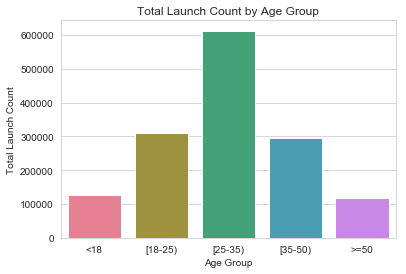

```python
plt.title("Total Launch Count by Age Group")
sns.barplot(x = 'AgeGroup',y="TotalLaunchCount",
                data=df_age_launcher,palette=age_color,order=["<18", "[18-25)",'[25-35)','[35-50)','>=50'])
plt.xlabel('Age Group')
plt.ylabel('Total Launch Count')
```

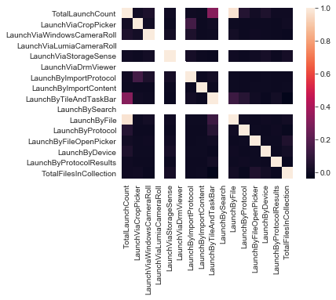

```python
wh2 = df[["TotalLaunchCount",
"LaunchViaCropPicker",
"LaunchViaWindowsCameraRoll",
"LaunchViaLumiaCameraRoll",
"LaunchViaStorageSense",
"LaunchViaDrmViewer",
"LaunchByImportProtocol",
"LaunchByImportContent",
"LaunchByTileAndTaskBar",
"LaunchBySearch",
"LaunchByFile",
"LaunchByProtocol",
"LaunchByFileOpenPicker",
"LaunchByDevice",
"LaunchByProtocolResults",
         'TotalFilesInCollection']] #Subsetting the data

cor = wh2.corr() #Calculate the correlation of the above variables
sns.heatmap(cor, square = True) #Plot the correlation as heat map
```

- Launch by tile and task bar / Launch by file seem to be most influential on actual launch count but nothing seems to influence storage & usage

# 4. Pre Model Prep

```python
for col in ['CountryShortName','FormFactor', 'AgeGroup', 'Gender', 'MostUsedPhotoApp']:
    df[col] = df[col].astype('category')

df_new = df[['AgeGroup', 'FormFactor','Gender']]
df_newer = pd.get_dummies(df_new)
df_newest = pd.concat([df, df_newer], axis=1)

df_newest.head()
```

|  | UserId | CountryShortName | IsTouchEnabled | FormFactor | NumberOfActiveDaysInPhotosApp | TotalLaunchCount | LaunchViaCropPicker | LaunchViaWindowsCameraRoll | LaunchViaLumiaCameraRoll | LaunchViaStorageSense | ... | AgeGroup_[25-35) | AgeGroup_[35-50) | FormFactor_AllInOne | FormFactor_Desktop | FormFactor_LargeTablet | FormFactor_Notebook | FormFactor_Other | FormFactor_SmallTablet | Gender_F | Gender_M |
| --- | --- | --- | --- | --- | --- | --- | --- | --- | --- | --- | --- | --- | --- | --- | --- | --- | --- | --- | --- | --- | --- |
| 1 | 2 | Ukraine | 0 | Notebook | 2 | 3 | 0 | 0 | 0 | 0 | ... | 1 | 0 | 0 | 0 | 0 | 1 | 0 | 0 | 0 | 1 |
| 2 | 3 | China | 0 | Desktop | 1 | 1 | 0 | 0 | 0 | 0 | ... | 0 | 1 | 0 | 1 | 0 | 0 | 0 | 0 | 0 | 1 |
| 3 | 4 | Slovakia | 0 | Notebook | 2 | 5 | 0 | 0 | 0 | 0 | ... | 0 | 0 | 0 | 0 | 0 | 1 | 0 | 0 | 0 | 1 |
| 4 | 5 | Morocco | 0 | Notebook | 5 | 8 | 0 | 0 | 0 | 0 | ... | 0 | 0 | 0 | 0 | 0 | 1 | 0 | 0 | 0 | 1 |
| 5 | 6 | United States | 0 | Desktop | 1 | 3 | 0 | 0 | 0 | 0 | ... | 1 | 0 | 0 | 1 | 0 | 0 | 0 | 0 | 1 | 0 |

5 rows × 63 columns

- Above: Convert data categories for manipulation & generate one hot encoding
- Below: Drop unecessary columns

```python
df_cluster = df_newest.drop(['UserId','CountryShortName', 'FormFactor','AgeGroup', 'Gender', 'MostUsedPhotoApp'], axis = 1, inplace = False)
df_cluster.head()
```

|  | IsTouchEnabled | NumberOfActiveDaysInPhotosApp | TotalLaunchCount | LaunchViaCropPicker | LaunchViaWindowsCameraRoll | LaunchViaLumiaCameraRoll | LaunchViaStorageSense | LaunchViaDrmViewer | LaunchByImportProtocol | LaunchByImportContent | ... | AgeGroup_[25-35) | AgeGroup_[35-50) | FormFactor_AllInOne | FormFactor_Desktop | FormFactor_LargeTablet | FormFactor_Notebook | FormFactor_Other | FormFactor_SmallTablet | Gender_F | Gender_M |
| --- | --- | --- | --- | --- | --- | --- | --- | --- | --- | --- | --- | --- | --- | --- | --- | --- | --- | --- | --- | --- | --- |
| 1 | 0 | 2 | 3 | 0 | 0 | 0 | 0 | 0 | 0 | 0 | ... | 1 | 0 | 0 | 0 | 0 | 1 | 0 | 0 | 0 | 1 |
| 2 | 0 | 1 | 1 | 0 | 0 | 0 | 0 | 0 | 0 | 0 | ... | 0 | 1 | 0 | 1 | 0 | 0 | 0 | 0 | 0 | 1 |
| 3 | 0 | 2 | 5 | 0 | 0 | 0 | 0 | 0 | 0 | 0 | ... | 0 | 0 | 0 | 0 | 0 | 1 | 0 | 0 | 0 | 1 |
| 4 | 0 | 5 | 8 | 0 | 0 | 0 | 0 | 0 | 0 | 0 | ... | 0 | 0 | 0 | 0 | 0 | 1 | 0 | 0 | 0 | 1 |
| 5 | 0 | 1 | 3 | 0 | 0 | 0 | 0 | 0 | 0 | 0 | ... | 1 | 0 | 0 | 1 | 0 | 0 | 0 | 0 | 1 | 0 |

5 rows × 57 columns

- Normalize continuous columns

```python
from sklearn.preprocessing import StandardScaler
scaler = StandardScaler()
int_data = df_cluster[['NumberOfActiveDaysInPhotosApp',
'TotalLaunchCount',
'LaunchViaCropPicker',
'LaunchViaWindowsCameraRoll',
'LaunchViaLumiaCameraRoll',
'LaunchViaStorageSense',
'LaunchViaDrmViewer',
'LaunchByImportProtocol',
'LaunchByImportContent',
'LaunchByTileAndTaskBar',
'LaunchBySearch',
'LaunchByFile',
'LaunchByProtocol',
'LaunchByFileOpenPicker',
'LaunchByDevice',
'LaunchByProtocolResults',
'PicturesViewed',
'VideosViewed',
'ImageEdit',
'VideoTrimEdit',
'SlideShowStarted',
'ImportSessionStarted',
'ShareSessions',
'PrintSessions',
'ItemsShared',
'ItemsDelete',
'ItemsCopied',
'ItemsImported',
'FromLocal',
'FromOneDrive',
'NumberOfImages',
'NumberOfVideos',
'NumberOfPanos',
'NumberOfRichMedia',
'TotalFilesInCollection',
'NumberOfActiveDaysInOS',
'TotalTimeInAllAppsInMins',
'TotalTimeInAllPhotosAppsInMins',
'TotalTimeInPhotosAppInMins',
'TotalTimeInOtherPhotosAppsInMins']]
names = int_data.columns
int_data = scaler.fit_transform(int_data)
df_cluster.loc[:,names] = int_data
#df_cluster.info()
```

[output not shown]

# 5. Modelling

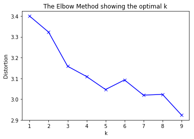

```python
from sklearn.cluster import KMeans
from sklearn import metrics
from scipy.spatial.distance import cdist

# create new plot and data
plt.plot()
X = df_cluster
colors = ['b', 'g', 'r']
markers = ['o', 'v', 's']

# k means determine k
distortions = []
K = range(1,10)
for k in K:
    kmeanModel = KMeans(n_clusters=k).fit(X)
    kmeanModel.fit(X)
    distortions.append(sum(np.min(cdist(X, kmeanModel.cluster_centers_, 'euclidean'), axis=1)) / X.shape[0])

# Plot the elbow
plt.plot(K, distortions, 'bx-')
plt.xlabel('k')
plt.ylabel('Distortion')
plt.title('The Elbow Method showing the optimal k')
plt.show()
```

- Attempts to find the optimal cluster count based on cluster density & distance - fluctuates slightly over runs

```python
km = KMeans(n_clusters=4).fit(df_cluster)

cluster_map = pd.DataFrame()
cluster_map['data_index'] = df_cluster.index.values
cluster_map['cluster'] = km.labels_
cluster_map.info()
```

```
<class 'pandas.core.frame.DataFrame'>
RangeIndex: 71047 entries, 0 to 71046
Data columns (total 2 columns):
data_index    71047 non-null int64
cluster       71047 non-null int32
dtypes: int32(1), int64(1)
memory usage: 832.7 KB
```

```python
#cluster_map.drop('data_index',axis = 1, inplace = True)
df = df.reset_index()

df = pd.concat([df, cluster_map], axis=1)
df.head()
```

|  | index | UserId | CountryShortName | IsTouchEnabled | FormFactor | NumberOfActiveDaysInPhotosApp | TotalLaunchCount | LaunchViaCropPicker | LaunchViaWindowsCameraRoll | LaunchViaLumiaCameraRoll | ... | AgeGroup | Gender | NumberOfActiveDaysInOS | TotalTimeInAllAppsInMins | TotalTimeInAllPhotosAppsInMins | MostUsedPhotoApp | TotalTimeInPhotosAppInMins | TotalTimeInOtherPhotosAppsInMins | data_index | cluster |
| --- | --- | --- | --- | --- | --- | --- | --- | --- | --- | --- | --- | --- | --- | --- | --- | --- | --- | --- | --- | --- | --- |
| 0 | 1 | 2 | Ukraine | 0 | Notebook | 2 | 3 | 0 | 0 | 0 | ... | [25-35) | M | 30 | 8740 | 1203 | App116 | 0 | 1203 | 1 | 1 |
| 1 | 2 | 3 | China | 0 | Desktop | 1 | 1 | 0 | 0 | 0 | ... | [35-50) | M | 28 | 12811 | 0 | Photos | 0 | 0 | 2 | 1 |
| 2 | 3 | 4 | Slovakia | 0 | Notebook | 2 | 5 | 0 | 0 | 0 | ... | >=50 | M | 16 | 1489 | 6 | Photos | 6 | 0 | 3 | 1 |
| 3 | 4 | 5 | Morocco | 0 | Notebook | 5 | 8 | 0 | 0 | 0 | ... | [18-25) | M | 30 | 12296 | 17 | Photos | 8 | 9 | 4 | 1 |
| 4 | 5 | 6 | United States | 0 | Desktop | 1 | 3 | 0 | 0 | 0 | ... | [25-35) | F | 21 | 3138 | 1 | App115 | 0 | 1 | 5 | 1 |

5 rows × 53 columns

# 6. Result Analysis

```python
#adjusts for outliers
df_outlier = df[df['TotalFilesInCollection'] < 50000]
df_clusters = df_outlier.groupby('cluster')['TotalTimeInAllAppsInMins','TotalTimeInPhotosAppInMins',
                                          'TotalTimeInOtherPhotosAppsInMins'
                                          ,'TotalTimeInAllPhotosAppsInMins','NumberOfImages','NumberOfVideos',
                                         'NumberOfActiveDaysInOS','FromLocal','FromOneDrive', 'TotalFilesInCollection'].apply(lambda x : x.astype(int).sum())
df2022=df_outlier['cluster'].value_counts().sort_index().to_frame()
df_clusters['total_people'] = df2022['cluster']


df2122 = df.groupby('cluster')['MostUsedPhotoApp'].value_counts().to_frame()
df2122 = df.groupby('cluster')['MostUsedPhotoApp'].first().to_frame()
df_clusters['Most_Used'] = df2122['MostUsedPhotoApp']

df_aged = df[df['Gender']=='M']
df20222=df_aged['cluster'].value_counts().sort_index().to_frame()
df_clusters['total_males'] = df20222['cluster']

df_aged = df[df['Gender']=='F']
df202222=df_aged['cluster'].value_counts().sort_index().to_frame()
df_clusters['total_females'] = df202222['cluster']

df_clusters = df_clusters.reset_index()
df_clusters['Average_Days'] = df_clusters['NumberOfActiveDaysInOS'] / df_clusters['total_people']
df_clusters['Average_All_Apps'] = df_clusters['TotalTimeInAllAppsInMins'] / df_clusters['total_people']
df_clusters['Average_Photos'] = df_clusters['TotalTimeInPhotosAppInMins'] / df_clusters['total_people']
df_clusters['Average_Others'] = df_clusters['TotalTimeInOtherPhotosAppsInMins'] / df_clusters['total_people']
df_clusters['Average_Total'] = df_clusters['TotalFilesInCollection'] / df_clusters['total_people']
df_clusters['Average_Pics'] = df_clusters['NumberOfImages'] / df_clusters['total_people']
df_clusters['Average_OneDrive'] = df_clusters['FromOneDrive'] / df_clusters['total_people']
df_clusters['Average_Local'] = df_clusters['FromLocal'] / df_clusters['total_people']
df_clusters['Photo_Other_Deficit'] = (df_clusters['Average_Photos'] - df_clusters['Average_Others']) / (df_clusters['Average_Photos'] + df_clusters['Average_Others'])
df_clusters['Local_One_Drive_Deficit'] = (df_clusters['Average_OneDrive'] - df_clusters['Average_Local']) / (df_clusters['Average_OneDrive'] + df_clusters['Average_Local'])
df_clusters['PhotoApp'] = df_clusters['TotalTimeInPhotosAppInMins']  / df_clusters['TotalTimeInAllAppsInMins']
df_clusters.head(20)
```

|  | cluster | TotalTimeInAllAppsInMins | TotalTimeInPhotosAppInMins | TotalTimeInOtherPhotosAppsInMins | TotalTimeInAllPhotosAppsInMins | NumberOfImages | NumberOfVideos | NumberOfActiveDaysInOS | FromLocal | FromOneDrive | ... | Average_All_Apps | Average_Photos | Average_Others | Average_Total | Average_Pics | Average_OneDrive | Average_Local | Photo_Other_Deficit | Local_One_Drive_Deficit | PhotoApp |
| --- | --- | --- | --- | --- | --- | --- | --- | --- | --- | --- | --- | --- | --- | --- | --- | --- | --- | --- | --- | --- | --- |
| 0 | 0 | 8295886 | 28689 | 53398 | 82087 | 25173988 | 557124 | 22364 | 14403138 | 10259227 | ... | 7745.925303 | 26.787115 | 49.858077 | 24061.985994 | 23505.124183 | 9579.110177 | 13448.308123 | -0.301010 | -0.168026 | 0.003458 |
| 1 | 1 | 393258473 | 651960 | 2423711 | 3075671 | 56556474 | 1085523 | 1127632 | 33762646 | 21476582 | ... | 6288.915643 | 10.426022 | 38.759531 | 922.708581 | 904.440510 | 343.449466 | 539.925894 | -0.576053 | -0.222416 | 0.001658 |
| 2 | 2 | 81785919 | 196160 | 1347886 | 1544046 | 2389745 | 11339 | 8271 | 348760 | 1713775 | ... | 282020.410345 | 676.413793 | 4647.882759 | 8280.403448 | 8240.500000 | 5909.568966 | 1202.620690 | -0.745914 | 0.661814 | 0.002398 |
| 3 | 3 | 73117465 | 496541 | 630815 | 1127356 | 5754451 | 98246 | 165699 | 4234121 | 1367784 | ... | 10390.431292 | 70.561461 | 89.642603 | 832.212448 | 817.742078 | 194.370328 | 601.694046 | -0.119105 | -0.511672 | 0.006791 |

4 rows × 26 columns

### Initial thoughts:

```python
print(df.groupby('cluster')['Gender'].value_counts())
```

```
cluster  Gender
0        M          1033
         F           146
1        M         51659
         F         10873
2        M           281
         F            18
3        M          5716
         F          1321
Name: Gender, dtype: int64
```

- Cluster 2 power users lean heavily male
- Cluster 0 the second most active also has a low female population.
- Cluster 3 & 1 are more balanced at a 5-1 ratio

```python
print(df.groupby('cluster')['AgeGroup'].value_counts())
```

```
cluster  AgeGroup
0        [35-50)       465
         [25-35)       370
         >=50          177
         [18-25)       133
         <18            34
1        [25-35)     25009
         [35-50)     13327
         [18-25)     13235
         >=50         6049
         <18          4912
2        [35-50)       136
         [18-25)        73
         [25-35)        61
         >=50           25
         <18             4
3        [25-35)      3075
         [18-25)      1434
         [35-50)      1316
         <18           717
         >=50          495
Name: AgeGroup, dtype: int64
```

- The more active groups, 0 & 2, skew a bit older & male
- following gender tables back this up

```python
print(df[df['Gender'] != 'M'].groupby('cluster')['AgeGroup'].value_counts())
```

```
cluster  AgeGroup
0        [25-35)       62
         [35-50)       44
         >=50          16
         <18           13
         [18-25)       11
1        [25-35)     4556
         <18         2216
         [18-25)     1947
         [35-50)     1520
         >=50         634
2        [18-25)       12
         [25-35)        5
         [35-50)        1
3        [25-35)      421
         <18          377
         [18-25)      233
         [35-50)      226
         >=50          64
Name: AgeGroup, dtype: int64
```

```python
print(df[df['Gender'] != 'F'].groupby('cluster')['AgeGroup'].value_counts())
```

```
cluster  AgeGroup
0        [35-50)       421
         [25-35)       308
         >=50          161
         [18-25)       122
         <18            21
1        [25-35)     20453
         [35-50)     11807
         [18-25)     11288
         >=50         5415
         <18          2696
2        [35-50)       135
         [18-25)        61
         [25-35)        56
         >=50           25
         <18             4
3        [25-35)      2654
         [18-25)      1201
         [35-50)      1090
         >=50          431
         <18           340
Name: AgeGroup, dtype: int64
```

```python
print(df[df['cluster'] == 1].groupby('AgeGroup')['FormFactor'].value_counts())
```

```
AgeGroup  FormFactor
<18       Notebook        2544
          Desktop         2171
          Other             99
          AllInOne          49
          LargeTablet       44
          SmallTablet        5
>=50      Notebook        2886
          Desktop         2613
          LargeTablet      233
          Other            209
          AllInOne          90
          SmallTablet       18
[18-25)   Notebook        7923
          Desktop         4691
          Other            309
          LargeTablet      200
          AllInOne          88
          SmallTablet       24
[25-35)   Notebook       13830
          Desktop         9543
          Other            702
          LargeTablet      538
          AllInOne         373
          SmallTablet       23
[35-50)   Notebook        6965
          Desktop         5211
          LargeTablet      532
          Other            372
          AllInOne         202
          SmallTablet       45
Name: FormFactor, dtype: int64
```

```python
print(df[df['cluster'] == 3].groupby('AgeGroup')['FormFactor'].value_counts())
```

```
AgeGroup  FormFactor
<18       Desktop         354
          Notebook        342
          Other            12
          AllInOne          5
          LargeTablet       4
>=50      Notebook        239
          Desktop         225
          Other            13
          AllInOne         10
          LargeTablet       8
[18-25)   Notebook        842
          Desktop         552
          Other            26
          LargeTablet       8
          AllInOne          5
          SmallTablet       1
[25-35)   Notebook       1718
          Desktop        1239
          Other            49
          AllInOne         38
          LargeTablet      30
          SmallTablet       1
[35-50)   Notebook        646
          Desktop         615
          Other            26
          LargeTablet      17
          AllInOne         12
Name: FormFactor, dtype: int64
```

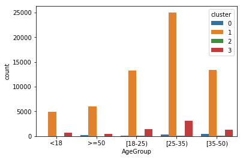

```python
ax = sns.countplot(x="AgeGroup", hue = 'cluster',data=df)
```

- Graphic confirms that cluster 1 & 3 lean towards a more general population distribution.

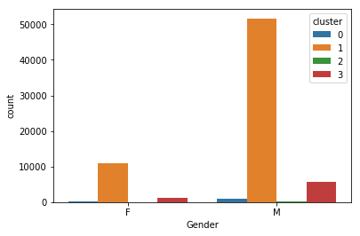

```python
ax = sns.countplot(x="Gender", hue = 'cluster',data=df)
```

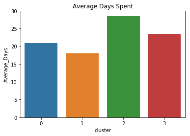

```python
plt.title("Average Days Spent")
sns.barplot(x="cluster", y="Average_Days", data=df_clusters)
```

- Shows engagmenet level by cluster - active number of days.
- Cluster 3 shows almost an equal level of engagement to the power users

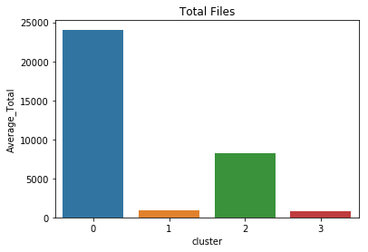

```python
plt.title("Total Files")
sns.barplot(x="cluster", y="Average_Total", data=df_clusters)
```

- I suspect there could be outlier issues in cluster 0. Worth investigating further before making concrete decisions.
  - This cluster leans older so this is potentially a couple very proud grandparents.
- Total file count for cluster 2 confirms they are already heavy users.

# 7. Conclusion

1. Final recommendation would be to target cluster 3. A lot of their attributes match up with the largest group cluster 1 so you could appeal to the 2 largest growth groups by developing features for 3. Cluster 2 are probably some sort of photoshop or advanced picture editor user so it's debatable if it's worth the time to compete with that product.
2. One thing I would like to dig in further is what affect country has on it. There would need to be some consolidation under region or economic development level.
3. Primary concern with the model is that it doesnt accurately capture the full dataset since clustering can't take full advantage of categorical data. With more time I'd be interested in adding a k-modes model which can handle categorical & numerical data. Photo storage on the computer doesn't seem to be the norm with such an emphais on mobile so the data could be biased & not generalize to actual users.